# Introduction

### Made by: Keilani Li

Hello! The goal of my project is to identify characteristics or behavioral patterns of people experiencing mental health issues. To reach my goal, I plan to analyze features from a mental health dataset from Kaggle and train a clustering model. Some of these features include signs of stress, mood swings, changes in habit, and other factors. I decided to use a clustering model since it's more appropriate for my goal and also because I wanted to practice it more.

I decided to choose this topic to promote mental health awareness. If we are able to figure out the behavioral patterns of people going through mental health struggles, it may encourage them to seek professional help to address those issues. Better yet, if we could recognize these signs of struggle in the people around us, we could offer them supportive resources since we know that they're going through something.

# Background

As mentioned before, the dataset we'll be looking at is from Kaggle.com and it can be viewed or downloaded by visiting this link: https://www.kaggle.com/datasets/divaniazzahra/mental-health-dataset/data. It consists of 17 columns with over 290,000 rows.

Based on the dataset description on Kaggle, the data was gathered through a global survey during a specific time period with the intention to track mental health trends of people all over the world with various backgrounds.

## Step 1: Cleaning data

First, I will import various Python libraries that will be used to perform data cleaning, data visualization, and finally, data analysis. I'll also need to clean the data in case there are null values and I would need to change text string data into numbers (encoding the data).

```python
# importing modules
import numpy as np
import pandas as pd
import matplotlib.pyplot as plt
import seaborn as sns

from sklearn.cluster import KMeans
from sklearn import metrics

# work around for multi-threading problem of kmeans algorithm on Windows
import os
os.environ["OMP_NUM_THREADS"] = "1"
```

```python
mh = pd.read_csv("Mental Health Dataset.csv")
print("Number of (rows, columns):", mh.shape)
mh.head()
```

```
Number of (rows, columns): (292364, 17)
```

|  | Timestamp | Gender | Country | Occupation | self_employed | family_history | treatment | Days_Indoors | Growing_Stress | Changes_Habits | Mental_Health_History | Mood_Swings | Coping_Struggles | Work_Interest | Social_Weakness | mental_health_interview | care_options |
| --- | --- | --- | --- | --- | --- | --- | --- | --- | --- | --- | --- | --- | --- | --- | --- | --- | --- |
| 0 | 2014-08-27 11:29:31 | Female | United States | Corporate | NaN | No | Yes | 1-14 days | Yes | No | Yes | Medium | No | No | Yes | No | Not sure |
| 1 | 2014-08-27 11:31:50 | Female | United States | Corporate | NaN | Yes | Yes | 1-14 days | Yes | No | Yes | Medium | No | No | Yes | No | No |
| 2 | 2014-08-27 11:32:39 | Female | United States | Corporate | NaN | Yes | Yes | 1-14 days | Yes | No | Yes | Medium | No | No | Yes | No | Yes |
| 3 | 2014-08-27 11:37:59 | Female | United States | Corporate | No | Yes | Yes | 1-14 days | Yes | No | Yes | Medium | No | No | Yes | Maybe | Yes |
| 4 | 2014-08-27 11:43:36 | Female | United States | Corporate | No | Yes | Yes | 1-14 days | Yes | No | Yes | Medium | No | No | Yes | No | Yes |

After loading in the data, we are able to see that there are a total of 292,364 rows in this dataset. The first few lines of data also shows a few NaN (empty) values which are not ideal and will need to be removed.

```python
print(mh.isna().sum())
```

```
Timestamp                     0
Gender                        0
Country                       0
Occupation                    0
self_employed              5202
family_history                0
treatment                     0
Days_Indoors                  0
Growing_Stress                0
Changes_Habits                0
Mental_Health_History         0
Mood_Swings                   0
Coping_Struggles              0
Work_Interest                 0
Social_Weakness               0
mental_health_interview       0
care_options                  0
dtype: int64
```

The first line of code shows us that there are 5202 rows with empty values. Since the data was gathered from a survey, sometimes people choose to not answer some questions. I will **drop** these rows because I want to use real values and I don't want invalid data to affect the model that will be trained later.

```python
mh = mh.dropna()
print("Number of (rows, columns) after cleaning:", mh.shape)
mh # confirming we dropped NaN rows
```

```
Number of (rows, columns) after cleaning: (287162, 17)
```

|  | Timestamp | Gender | Country | Occupation | self_employed | family_history | treatment | Days_Indoors | Growing_Stress | Changes_Habits | Mental_Health_History | Mood_Swings | Coping_Struggles | Work_Interest | Social_Weakness | mental_health_interview | care_options |
| --- | --- | --- | --- | --- | --- | --- | --- | --- | --- | --- | --- | --- | --- | --- | --- | --- | --- |
| 3 | 2014-08-27 11:37:59 | Female | United States | Corporate | No | Yes | Yes | 1-14 days | Yes | No | Yes | Medium | No | No | Yes | Maybe | Yes |
| 4 | 2014-08-27 11:43:36 | Female | United States | Corporate | No | Yes | Yes | 1-14 days | Yes | No | Yes | Medium | No | No | Yes | No | Yes |
| 5 | 2014-08-27 11:49:51 | Female | Poland | Corporate | No | No | Yes | 1-14 days | Yes | No | Yes | Medium | No | No | Yes | Maybe | Not sure |
| 6 | 2014-08-27 11:51:34 | Female | Australia | Corporate | No | Yes | Yes | 1-14 days | Yes | No | Yes | Medium | No | No | Yes | No | Not sure |
| 7 | 2014-08-27 11:52:41 | Female | United States | Corporate | No | No | No | 1-14 days | Yes | No | Yes | Medium | No | No | Yes | No | No |
| ... | ... | ... | ... | ... | ... | ... | ... | ... | ... | ... | ... | ... | ... | ... | ... | ... | ... |
| 292359 | 2015-07-27 23:25:34 | Male | United States | Business | Yes | Yes | Yes | 15-30 days | No | Maybe | No | Low | Yes | No | Maybe | Maybe | Not sure |
| 292360 | 2015-08-17 09:38:35 | Male | South Africa | Business | No | Yes | Yes | 15-30 days | No | Maybe | No | Low | Yes | No | Maybe | No | Yes |
| 292361 | 2015-08-25 19:59:38 | Male | United States | Business | No | Yes | No | 15-30 days | No | Maybe | No | Low | Yes | No | Maybe | No | No |
| 292362 | 2015-09-26 01:07:35 | Male | United States | Business | No | Yes | Yes | 15-30 days | No | Maybe | No | Low | Yes | No | Maybe | No | Yes |
| 292363 | 2016-02-01 23:04:31 | Male | United States | Business | No | Yes | Yes | 15-30 days | No | Maybe | No | Low | Yes | No | Maybe | No | Yes |

287162 rows × 17 columns

```python
mh.reset_index(inplace = True)
mh.drop(columns = ['index'], inplace = True)
mh # confirming the indexes are now continuous
```

|  | Timestamp | Gender | Country | Occupation | self_employed | family_history | treatment | Days_Indoors | Growing_Stress | Changes_Habits | Mental_Health_History | Mood_Swings | Coping_Struggles | Work_Interest | Social_Weakness | mental_health_interview | care_options |
| --- | --- | --- | --- | --- | --- | --- | --- | --- | --- | --- | --- | --- | --- | --- | --- | --- | --- |
| 0 | 2014-08-27 11:37:59 | Female | United States | Corporate | No | Yes | Yes | 1-14 days | Yes | No | Yes | Medium | No | No | Yes | Maybe | Yes |
| 1 | 2014-08-27 11:43:36 | Female | United States | Corporate | No | Yes | Yes | 1-14 days | Yes | No | Yes | Medium | No | No | Yes | No | Yes |
| 2 | 2014-08-27 11:49:51 | Female | Poland | Corporate | No | No | Yes | 1-14 days | Yes | No | Yes | Medium | No | No | Yes | Maybe | Not sure |
| 3 | 2014-08-27 11:51:34 | Female | Australia | Corporate | No | Yes | Yes | 1-14 days | Yes | No | Yes | Medium | No | No | Yes | No | Not sure |
| 4 | 2014-08-27 11:52:41 | Female | United States | Corporate | No | No | No | 1-14 days | Yes | No | Yes | Medium | No | No | Yes | No | No |
| ... | ... | ... | ... | ... | ... | ... | ... | ... | ... | ... | ... | ... | ... | ... | ... | ... | ... |
| 287157 | 2015-07-27 23:25:34 | Male | United States | Business | Yes | Yes | Yes | 15-30 days | No | Maybe | No | Low | Yes | No | Maybe | Maybe | Not sure |
| 287158 | 2015-08-17 09:38:35 | Male | South Africa | Business | No | Yes | Yes | 15-30 days | No | Maybe | No | Low | Yes | No | Maybe | No | Yes |
| 287159 | 2015-08-25 19:59:38 | Male | United States | Business | No | Yes | No | 15-30 days | No | Maybe | No | Low | Yes | No | Maybe | No | No |
| 287160 | 2015-09-26 01:07:35 | Male | United States | Business | No | Yes | Yes | 15-30 days | No | Maybe | No | Low | Yes | No | Maybe | No | Yes |
| 287161 | 2016-02-01 23:04:31 | Male | United States | Business | No | Yes | Yes | 15-30 days | No | Maybe | No | Low | Yes | No | Maybe | No | Yes |

287162 rows × 17 columns

After dropping empty rows, we are left with 287,162 rows to work with. I also reset the index numbers so we don't have gaps and we can work with continuous rows. The reset_index() function creates a new column with the previous indexes, so I have to drop index column before moving on. Before I start analyzing each column, I'll make every column name in lowercase for better readability.

```python
print('Lowering column names:')
mh.columns = mh.columns.str.lower()
mh.head()
```

```
Lowering column names:
```

|  | timestamp | gender | country | occupation | self_employed | family_history | treatment | days_indoors | growing_stress | changes_habits | mental_health_history | mood_swings | coping_struggles | work_interest | social_weakness | mental_health_interview | care_options |
| --- | --- | --- | --- | --- | --- | --- | --- | --- | --- | --- | --- | --- | --- | --- | --- | --- | --- |
| 0 | 2014-08-27 11:37:59 | Female | United States | Corporate | No | Yes | Yes | 1-14 days | Yes | No | Yes | Medium | No | No | Yes | Maybe | Yes |
| 1 | 2014-08-27 11:43:36 | Female | United States | Corporate | No | Yes | Yes | 1-14 days | Yes | No | Yes | Medium | No | No | Yes | No | Yes |
| 2 | 2014-08-27 11:49:51 | Female | Poland | Corporate | No | No | Yes | 1-14 days | Yes | No | Yes | Medium | No | No | Yes | Maybe | Not sure |
| 3 | 2014-08-27 11:51:34 | Female | Australia | Corporate | No | Yes | Yes | 1-14 days | Yes | No | Yes | Medium | No | No | Yes | No | Not sure |
| 4 | 2014-08-27 11:52:41 | Female | United States | Corporate | No | No | No | 1-14 days | Yes | No | Yes | Medium | No | No | Yes | No | No |

After looking at the column names, I think that the **treatment feature best represents mental health struggles**, so I will base my clusters off of that. This is because that some people may have severe symptoms that propel them to seek professional help (i.e medicine or therapy), but others may have mild symptoms and don't need treatment to ease their struggles.

## Step 2: Preparing data

Now that our data is cleaned, I need to make sure I remove any other features that don't have any correlation with treatment before I train the clustering model.

Let's start with the timestamp column. It seems like the survey collected data over a few years. Since timestamps are unique to each survey submission, **I will drop the column** because it does not provide information on behavioral responses. But I am curious about how much of the data was gathered in certain years, so I will extract the year before removing the column.

```python
print('Extracting the year in the timestamp column:')
mh['timestamp'] = mh['timestamp'].str.extract(r'^(\d{4})')
mh.head()
```

```
Extracting the year in the timestamp column:
```

|  | timestamp | gender | country | occupation | self_employed | family_history | treatment | days_indoors | growing_stress | changes_habits | mental_health_history | mood_swings | coping_struggles | work_interest | social_weakness | mental_health_interview | care_options |
| --- | --- | --- | --- | --- | --- | --- | --- | --- | --- | --- | --- | --- | --- | --- | --- | --- | --- |
| 0 | 2014 | Female | United States | Corporate | No | Yes | Yes | 1-14 days | Yes | No | Yes | Medium | No | No | Yes | Maybe | Yes |
| 1 | 2014 | Female | United States | Corporate | No | Yes | Yes | 1-14 days | Yes | No | Yes | Medium | No | No | Yes | No | Yes |
| 2 | 2014 | Female | Poland | Corporate | No | No | Yes | 1-14 days | Yes | No | Yes | Medium | No | No | Yes | Maybe | Not sure |
| 3 | 2014 | Female | Australia | Corporate | No | Yes | Yes | 1-14 days | Yes | No | Yes | Medium | No | No | Yes | No | Not sure |
| 4 | 2014 | Female | United States | Corporate | No | No | No | 1-14 days | Yes | No | Yes | Medium | No | No | Yes | No | No |

```python
mh.timestamp.value_counts()
```

```
timestamp
2014    272078
2015     14694
2016       390
Name: count, dtype: int64
```

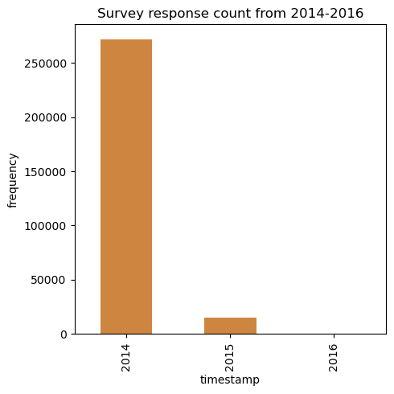

```python
plt.figure(figsize = (5, 5))
mh.timestamp.value_counts().plot(kind = 'bar', color = 'peru')
plt.title('Survey response count from 2014-2016')
plt.ylabel("frequency")
```

A majority of the data have been gathered in 2014 but other small amounts of data have been collected in 2015 and 2016. We can use this information in the end to tell us how mental health trends were during this time period, but it is not relevant for clustering. Let's **drop** the timestamp column and look at the gender column next.

```python
mh.drop(columns = ['timestamp'], inplace = True)
mh.head()
```

|  | gender | country | occupation | self_employed | family_history | treatment | days_indoors | growing_stress | changes_habits | mental_health_history | mood_swings | coping_struggles | work_interest | social_weakness | mental_health_interview | care_options |
| --- | --- | --- | --- | --- | --- | --- | --- | --- | --- | --- | --- | --- | --- | --- | --- | --- |
| 0 | Female | United States | Corporate | No | Yes | Yes | 1-14 days | Yes | No | Yes | Medium | No | No | Yes | Maybe | Yes |
| 1 | Female | United States | Corporate | No | Yes | Yes | 1-14 days | Yes | No | Yes | Medium | No | No | Yes | No | Yes |
| 2 | Female | Poland | Corporate | No | No | Yes | 1-14 days | Yes | No | Yes | Medium | No | No | Yes | Maybe | Not sure |
| 3 | Female | Australia | Corporate | No | Yes | Yes | 1-14 days | Yes | No | Yes | Medium | No | No | Yes | No | Not sure |
| 4 | Female | United States | Corporate | No | No | No | 1-14 days | Yes | No | Yes | Medium | No | No | Yes | No | No |

```python
mh.gender.value_counts()
```

```
gender
Male      235950
Female     51212
Name: count, dtype: int64
```

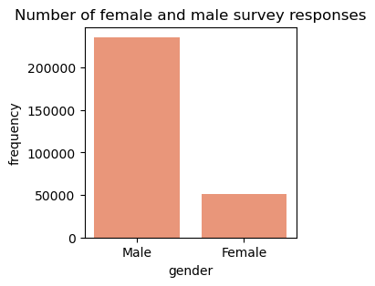

```python
plt.figure(figsize = (3, 3))
plt.bar(("Male", "Female"), (np.sum(mh.gender == "Male"), np.sum(mh.gender == "Female")), color = 'darksalmon')
plt.title("Number of female and male survey responses")
plt.xlabel("gender")
plt.ylabel("frequency")
```

The code shows us that there is an imbalance between males and females in the survey submissions as there are significantly more male answers than female. Although there may be differences in behavioral responses between genders, my goal is to look at only behavioral patterns so it doesn't matter which gender it is. Therefore, **I will be removing this column** because I don't want gender to affect the cluster model. Let's look at the country column.

```python
mh.country.value_counts()
```

```
country
United States             168056
United Kingdom             50624
Canada                     17556
Australia                   6026
Netherlands                 5894
Ireland                     5548
Germany                     4680
Sweden                      2818
India                       2774
France                      2340
Brazil                      2340
New Zealand                 1994
South Africa                1994
Switzerland                 1560
Israel                      1560
Italy                       1560
Belgium                      824
Poland                       824
Russia                       780
Denmark                      780
Singapore                    780
Greece                       780
Czech Republic               390
Georgia                      390
Colombia                     390
Moldova                      390
Mexico                       390
Croatia                      390
Thailand                     390
Nigeria                      390
Bosnia and Herzegovina       390
Portugal                     390
Finland                      390
Costa Rica                   390
Philippines                  390
Name: count, dtype: int64
```

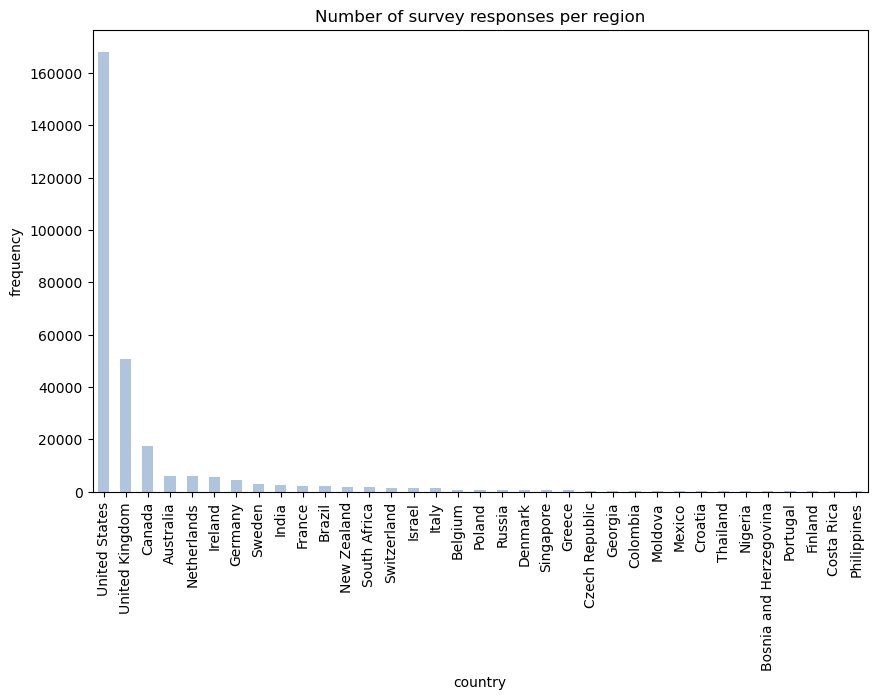

```python
plt.figure(figsize = (10, 6))
mh['country'].value_counts().plot(kind = 'bar', color = 'lightsteelblue')
plt.title('Number of survey responses per region')
plt.ylabel("frequency")
```

When looking at the countries column, we see that a lot of the data is from people in the USA, the UK, and Canada, but overall there is a large variety of countries. However, because I won't be comparing how mental health struggles differ from one country to another, **I will remove this column too** as it's not relevant to my goal.

```python
mh.drop(columns = ['gender', 'country'], inplace = True)
mh.head()
```

|  | occupation | self_employed | family_history | treatment | days_indoors | growing_stress | changes_habits | mental_health_history | mood_swings | coping_struggles | work_interest | social_weakness | mental_health_interview | care_options |
| --- | --- | --- | --- | --- | --- | --- | --- | --- | --- | --- | --- | --- | --- | --- |
| 0 | Corporate | No | Yes | Yes | 1-14 days | Yes | No | Yes | Medium | No | No | Yes | Maybe | Yes |
| 1 | Corporate | No | Yes | Yes | 1-14 days | Yes | No | Yes | Medium | No | No | Yes | No | Yes |
| 2 | Corporate | No | No | Yes | 1-14 days | Yes | No | Yes | Medium | No | No | Yes | Maybe | Not sure |
| 3 | Corporate | No | Yes | Yes | 1-14 days | Yes | No | Yes | Medium | No | No | Yes | No | Not sure |
| 4 | Corporate | No | No | No | 1-14 days | Yes | No | Yes | Medium | No | No | Yes | No | No |

To analyze our data, plots will be used to determine if there's a correlation between treatment and the feature, so we'll also need to turn the text strings into numbers. I'll make a new dataframe to store these replaced values so we can refer to the original dataframe for text string values when needed. Additionally, a lot of these features share the same values (yes, no, maybe), so it would be faster to replace them all at once.

```python
for feature in mh:
    print(f'{feature}:', mh[feature].unique(), '\n')
```

```
occupation: ['Corporate' 'Student' 'Business' 'Housewife' 'Others']

self_employed: ['No' 'Yes']

family_history: ['Yes' 'No']

treatment: ['Yes' 'No']

days_indoors: ['1-14 days' 'Go out Every day' 'More than 2 months' '15-30 days'
 '31-60 days']

growing_stress: ['Yes' 'No' 'Maybe']

changes_habits: ['No' 'Yes' 'Maybe']

mental_health_history: ['Yes' 'No' 'Maybe']

mood_swings: ['Medium' 'Low' 'High']

coping_struggles: ['No' 'Yes']

work_interest: ['No' 'Maybe' 'Yes']

social_weakness: ['Yes' 'No' 'Maybe']

mental_health_interview: ['Maybe' 'No' 'Yes']

care_options: ['Yes' 'Not sure' 'No']
```

```python
# turning occupation into numbers
job = mh['occupation'].unique()
replaceJob = dict(zip(job, np.arange(len(job))))
mh2 = mh.replace(replaceJob)
mh2.head()
```

|  | occupation | self_employed | family_history | treatment | days_indoors | growing_stress | changes_habits | mental_health_history | mood_swings | coping_struggles | work_interest | social_weakness | mental_health_interview | care_options |
| --- | --- | --- | --- | --- | --- | --- | --- | --- | --- | --- | --- | --- | --- | --- |
| 0 | 0 | No | Yes | Yes | 1-14 days | Yes | No | Yes | Medium | No | No | Yes | Maybe | Yes |
| 1 | 0 | No | Yes | Yes | 1-14 days | Yes | No | Yes | Medium | No | No | Yes | No | Yes |
| 2 | 0 | No | No | Yes | 1-14 days | Yes | No | Yes | Medium | No | No | Yes | Maybe | Not sure |
| 3 | 0 | No | Yes | Yes | 1-14 days | Yes | No | Yes | Medium | No | No | Yes | No | Not sure |
| 4 | 0 | No | No | No | 1-14 days | Yes | No | Yes | Medium | No | No | Yes | No | No |

```python
# turning yes, no, maybe, and not sure answer choices into numbers
yes_no_maybe_notsure = {"Yes" : 1,
                       "No" : 0,
                       "Maybe" : 0,
                       "Not sure" : 0}

mh2 = mh2.replace(yes_no_maybe_notsure)
mh2.head()
```

|  | occupation | self_employed | family_history | treatment | days_indoors | growing_stress | changes_habits | mental_health_history | mood_swings | coping_struggles | work_interest | social_weakness | mental_health_interview | care_options |
| --- | --- | --- | --- | --- | --- | --- | --- | --- | --- | --- | --- | --- | --- | --- |
| 0 | 0 | 0 | 1 | 1 | 1-14 days | 1 | 0 | 1 | Medium | 0 | 0 | 1 | 0 | 1 |
| 1 | 0 | 0 | 1 | 1 | 1-14 days | 1 | 0 | 1 | Medium | 0 | 0 | 1 | 0 | 1 |
| 2 | 0 | 0 | 0 | 1 | 1-14 days | 1 | 0 | 1 | Medium | 0 | 0 | 1 | 0 | 0 |
| 3 | 0 | 0 | 1 | 1 | 1-14 days | 1 | 0 | 1 | Medium | 0 | 0 | 1 | 0 | 0 |
| 4 | 0 | 0 | 0 | 0 | 1-14 days | 1 | 0 | 1 | Medium | 0 | 0 | 1 | 0 | 0 |

I decided to encode "maybe" and "not sure" values as zero because it would be helpful to know that the final result would be a for sure yes or a for sure no. It wouldn't help if someone were told "maybe" if they asked a friend about whether they've been experiencing mental health struggles.

```python
# turning amt of days indoors into numbers
indoors = mh['days_indoors'].unique()
replaceIndoors = dict(zip(indoors, np.arange(len(indoors))))
mh2 = mh2.replace(replaceIndoors)
mh2.head()
```

|  | occupation | self_employed | family_history | treatment | days_indoors | growing_stress | changes_habits | mental_health_history | mood_swings | coping_struggles | work_interest | social_weakness | mental_health_interview | care_options |
| --- | --- | --- | --- | --- | --- | --- | --- | --- | --- | --- | --- | --- | --- | --- |
| 0 | 0 | 0 | 1 | 1 | 0 | 1 | 0 | 1 | Medium | 0 | 0 | 1 | 0 | 1 |
| 1 | 0 | 0 | 1 | 1 | 0 | 1 | 0 | 1 | Medium | 0 | 0 | 1 | 0 | 1 |
| 2 | 0 | 0 | 0 | 1 | 0 | 1 | 0 | 1 | Medium | 0 | 0 | 1 | 0 | 0 |
| 3 | 0 | 0 | 1 | 1 | 0 | 1 | 0 | 1 | Medium | 0 | 0 | 1 | 0 | 0 |
| 4 | 0 | 0 | 0 | 0 | 0 | 1 | 0 | 1 | Medium | 0 | 0 | 1 | 0 | 0 |

```python
# turning mood swing values into numbers
mood = mh['mood_swings'].unique()
replaceMood = dict(zip(mood, np.arange(len(mood))))
mh2 = mh2.replace(replaceMood)
mh2.head()
```

|  | occupation | self_employed | family_history | treatment | days_indoors | growing_stress | changes_habits | mental_health_history | mood_swings | coping_struggles | work_interest | social_weakness | mental_health_interview | care_options |
| --- | --- | --- | --- | --- | --- | --- | --- | --- | --- | --- | --- | --- | --- | --- |
| 0 | 0 | 0 | 1 | 1 | 0 | 1 | 0 | 1 | 0 | 0 | 0 | 1 | 0 | 1 |
| 1 | 0 | 0 | 1 | 1 | 0 | 1 | 0 | 1 | 0 | 0 | 0 | 1 | 0 | 1 |
| 2 | 0 | 0 | 0 | 1 | 0 | 1 | 0 | 1 | 0 | 0 | 0 | 1 | 0 | 0 |
| 3 | 0 | 0 | 1 | 1 | 0 | 1 | 0 | 1 | 0 | 0 | 0 | 1 | 0 | 0 |
| 4 | 0 | 0 | 0 | 0 | 0 | 1 | 0 | 1 | 0 | 0 | 0 | 1 | 0 | 0 |

## Step 3: Analyzing data

Now that our data has been converted into numbers, we can now plot them on a graph. Let's look at a correlation heatmap to see how all the variables relate to each other.

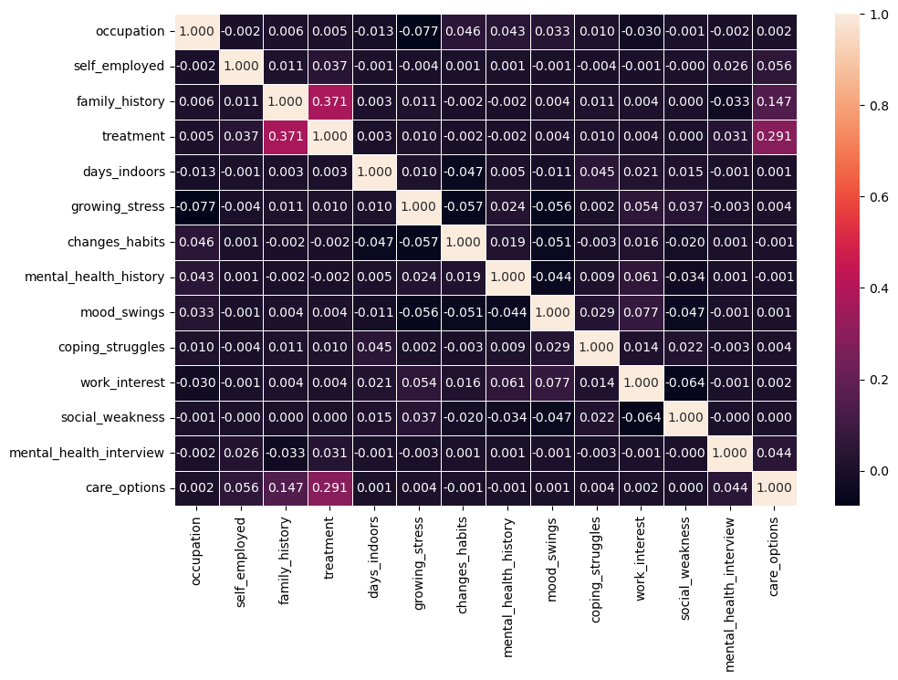

```python
plt.figure(figsize = (11, 7))
sns.heatmap(mh2.corr(), annot = True, fmt = '.3f', linewidth = 0.5)
```

The correlation heatmap reveals that there are some factors that have a higher correlation coefficient compared to others. For example, treatment and family history have a positive correlation coefficient of 0.37. We also see which features we can potentially drop based off the correlation heatmap because it has a coefficient of 0, meaning there is no correlation at all.

Although there are some correlation values near 0, I will still analyze each feature and their relevance to my goal. I'll use subplots for every 3 features to help us see the distributions between treatment and all the other features in the dataset. Let's look at the work-related features first.

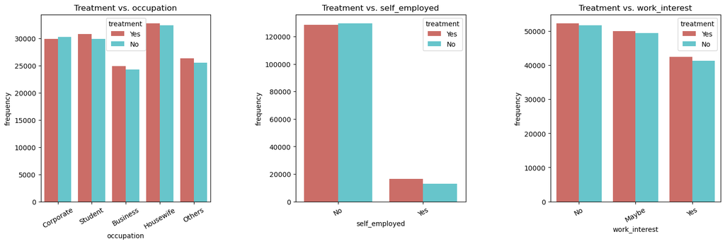

```python
plt.figure(figsize = (18, 5))
plt.subplots_adjust(hspace = 0.3, wspace = 0.5)

work_features = ['occupation', 'self_employed', 'work_interest']
for i, feature in enumerate(work_features):
    plt.subplot(1, 3, i + 1)
    sns.countplot(data = mh, x = feature, hue = 'treatment', palette = 'hls')
    plt.title(f"Treatment vs. {feature}")
    plt.xticks(rotation = 30)
    plt.ylabel("frequency")
```

Occupation: I do not think that the occupation feature would be helpful in the clustering model because no matter what job title you have, anyone can expereince mental health issues, so I'll **drop** this column. However, after we train the model, it may be helpful to see how symptoms differ between each job.

Self employed: This feature represents the distribution of respondents that are self-employed or not self-employed and their decision to seek treatment. I don't think that being self-employed is something that can affect behavioral patterns, so I will also **drop** this column.

Work interest: Unlike the other features, I do think that work interest can affect a person's mental health because their level of motivation can definitely influence behavioral patterns, so I'll **keep** this feature. For example, if a student isn't motivated because of internal (self-doubt, depression, etc.) or external (low grades, too much work, etc.) factors, they may exhibit behaviors like turning in assignments late.

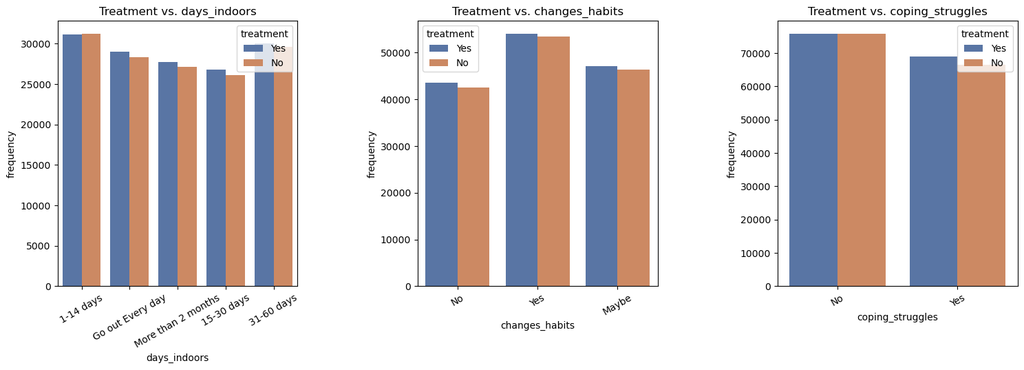

```python
plt.figure(figsize = (18, 5))
plt.subplots_adjust(hspace = 0.3, wspace = 0.5)

behavioral_features = ['days_indoors', 'changes_habits', 'coping_struggles']
for i, feature in enumerate(behavioral_features):
    plt.subplot(1, 3, i + 1)
    sns.countplot(data = mh, x = feature, hue = 'treatment', palette = 'deep')
    plt.title(f"Treatment vs. {feature}")
    plt.xticks(rotation = 30)
    plt.ylabel("frequency")
```

Days indoors: This feature represents the number of days respondents spend indoors. I do think that this feature can be a characteristic that influences mental health because it may reflect a respondent's motivation to spend time outside and it can also be a characteristic of social isolation. Although COVID did not happen when this survey was taken, it is a good example of how staying indoors affected people's mental health. During quarantine, people were required to stay inside, so it was hard to interact with other people and it took a toll on their mental health as a result. Therefore, I will **keep** this feature in the dataset.

Changes habits: This feature represents whether a respondent has experienced changes in habit. I think it could help indicate if someone is going through mental health problems because it may indicate that they are changing habits to adapt or cope with their struggles, so I'll **keep** this feature too. Since I'll be basing my clusters off of treatment, this feature is relevant to behavioral patterns because cognitive behavioral therapy is a type of treatment that addresses various types of behavior.

Coping struggles: This feature is basically the generalized version of the changes in habit feature. I do think it's worth **keeping** this feature in the dataset because it is a behavioral response that indicates how people deal with their struggles. If a respondent has a hard time dealing with their issues, it can influence them to seek treatment to deal with it in a more effective way.

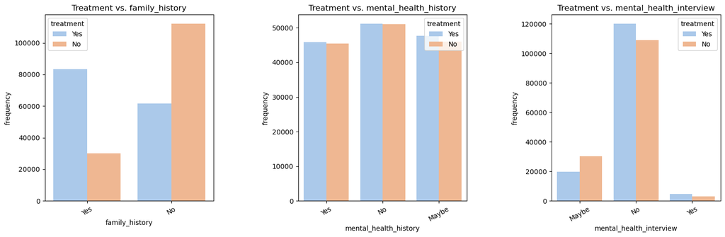

```python
plt.figure(figsize = (18, 5))
plt.subplots_adjust(hspace = 0.3, wspace = 0.5)

history_features = ['family_history', 'mental_health_history', 'mental_health_interview']
for i, feature in enumerate(history_features):
    plt.subplot(1, 3, i + 1)
    sns.countplot(data = mh, x = feature, hue = 'treatment', palette = 'pastel')
    plt.title(f"Treatment vs. {feature}")
    plt.xticks(rotation = 30)
    plt.ylabel("frequency")
```

Family history: This feature represents whether a respondent's family has a history of mental health disorders. I think it could help indicate mental health issues because genetics can play a role in mental health disorders, so it is important to **keep** this feature in the data.

Mental health history: This column is about whether or not the respondent has a mental health history. If they do, there is a chance their behavior patterns may recur which can aid the clustering model into determining what kind of behaviors can indicate that someone is struggling. Therefore, I think this is also an important feature to **keep** in the dataset.

Mental health interview: I do not think that going through a mental health interview contributes much to a respondent's behavioral response to mental health issues. Whether someone goes through with a mental health interview or not does not seem to greatly affect their choice to seek treatment. There is also a chance the respondent does not feel the need to be interviewed about their mental health because they're already aware of their issues, so I will **drop** this feature.

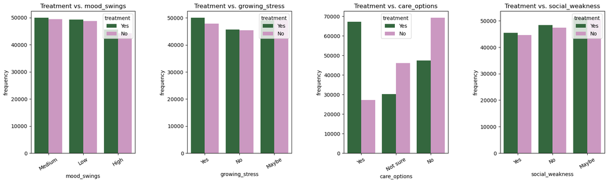

```python
plt.figure(figsize = (20, 5))
plt.subplots_adjust(hspace = 0.3, wspace = 0.5)

other_features = ['mood_swings', 'growing_stress', 'care_options', 'social_weakness']
for i, feature in enumerate(other_features):
    plt.subplot(1, 4, i + 1)
    sns.countplot(data = mh, x = feature, hue = 'treatment', palette = 'cubehelix')
    plt.title(f"Treatment vs. {feature}")
    plt.xticks(rotation = 30)
    plt.ylabel("frequency")
```

Care options: I think this feature would help with the clustering model because the availability of care options can definitely influence whether a respondent decides to seek treatment for their mental health problems or not. The graph shows us that respondents are more likely to seek help if they can utilize any available resources, and vice versa if they can't, but this is not the case for others. So, I'll **keep** this feature too.

Social weakness: This feature represents the respondent's difficulty with social aspects of life such as interactions or developing/maintaining relationships. Socializing is such an important part of personal growth and provides a sense of belonging and safety, so I think this is an important feature to **keep** in the dataset. It would also be beneficial to see how much social weakness can affect behavioral responses.

Now, we can finally drop the features we determined to be unnecessary and start training the model.

```python
mh2.drop(columns = ['occupation', 'self_employed', 'mental_health_interview'], inplace = True)
mh2.head()
```

|  | family_history | treatment | days_indoors | growing_stress | changes_habits | mental_health_history | mood_swings | coping_struggles | work_interest | social_weakness | care_options |
| --- | --- | --- | --- | --- | --- | --- | --- | --- | --- | --- | --- |
| 0 | 1 | 1 | 0 | 1 | 0 | 1 | 0 | 0 | 0 | 1 | 1 |
| 1 | 1 | 1 | 0 | 1 | 0 | 1 | 0 | 0 | 0 | 1 | 1 |
| 2 | 0 | 1 | 0 | 1 | 0 | 1 | 0 | 0 | 0 | 1 | 0 |
| 3 | 1 | 1 | 0 | 1 | 0 | 1 | 0 | 0 | 0 | 1 | 0 |
| 4 | 0 | 0 | 0 | 1 | 0 | 1 | 0 | 0 | 0 | 1 | 0 |

## Step 4: Training data

Now that our data is ready, we will train the K-Means clustering model. Before we fit our data into the clustering model, we need to know how many clusters is optimal for our dataset. The elbow curve can be used to help us find the ideal number of clusters for the model which will be represented by the variable k.

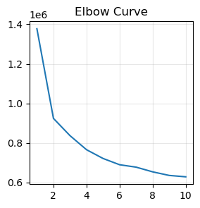

```python
# calculating the right k value
wcss = []
for i in range(1, 11):
    kmeans = KMeans(n_clusters = i, init = 'k-means++', n_init = 'auto')
    kmeans.fit(mh2)
    wcss.append(kmeans.inertia_)
fig = plt.figure(figsize = (3, 3))
plt.grid(alpha = 0.3)
plt.plot(np.arange(1, 11), wcss)
plt.title('Elbow Curve')
plt.show()
```

```python
kmeans = KMeans(n_clusters = 4, init = 'k-means++', n_init = 'auto')
kmeans.fit(mh2)
y_kmeans = kmeans.predict(mh2)
```

```python
cluster_df = pd.DataFrame()
cluster_df['data_index'] = mh2.index.values
cluster_df['cluster'] = y_kmeans
cluster_df
```

|  | data_index | cluster |
| --- | --- | --- |
| 0 | 0 | 2 |
| 1 | 1 | 2 |
| 2 | 2 | 2 |
| 3 | 3 | 2 |
| 4 | 4 | 2 |
| ... | ... | ... |
| 287157 | 287157 | 0 |
| 287158 | 287158 | 0 |
| 287159 | 287159 | 0 |
| 287160 | 287160 | 0 |
| 287161 | 287161 | 0 |

287162 rows × 2 columns

```python
print("Min cluster number:", min(y_kmeans))
print("Max cluster number:", max(y_kmeans))
```

```
Min cluster number: 0
Max cluster number: 3
```

After training the data, I've mapped each row of the dataframe to their respective cluster. We can use the indexes to find which rows make up each cluster in the original dataframe. I also displayed the max number of clusters just to be sure that we have 4 clusters since the head and tail of the dataset are in continuous order, so I don't want it to be misleading.

```python
for i in range(4):
    c = cluster_df[cluster_df['cluster'] == i]
    display(c)
```

|  | data_index | cluster |
| --- | --- | --- |
| 708 | 708 | 0 |
| 709 | 709 | 0 |
| 710 | 710 | 0 |
| 711 | 711 | 0 |
| 712 | 712 | 0 |
| ... | ... | ... |
| 287157 | 287157 | 0 |
| 287158 | 287158 | 0 |
| 287159 | 287159 | 0 |
| 287160 | 287160 | 0 |
| 287161 | 287161 | 0 |

72727 rows × 2 columns

|  | data_index | cluster |
| --- | --- | --- |
| 354 | 354 | 1 |
| 355 | 355 | 1 |
| 356 | 356 | 1 |
| 357 | 357 | 1 |
| 358 | 358 | 1 |
| ... | ... | ... |
| 286552 | 286552 | 1 |
| 286553 | 286553 | 1 |
| 286554 | 286554 | 1 |
| 286555 | 286555 | 1 |
| 286556 | 286556 | 1 |

90064 rows × 2 columns

|  | data_index | cluster |
| --- | --- | --- |
| 0 | 0 | 2 |
| 1 | 1 | 2 |
| 2 | 2 | 2 |
| 3 | 3 | 2 |
| 4 | 4 | 2 |
| ... | ... | ... |
| 285947 | 285947 | 2 |
| 285948 | 285948 | 2 |
| 285949 | 285949 | 2 |
| 285950 | 285950 | 2 |
| 285951 | 285951 | 2 |

63403 rows × 2 columns

|  | data_index | cluster |
| --- | --- | --- |
| 236 | 236 | 3 |
| 237 | 237 | 3 |
| 238 | 238 | 3 |
| 239 | 239 | 3 |
| 240 | 240 | 3 |
| ... | ... | ... |
| 284737 | 284737 | 3 |
| 284738 | 284738 | 3 |
| 284739 | 284739 | 3 |
| 284740 | 284740 | 3 |
| 284741 | 284741 | 3 |

60968 rows × 2 columns

This block of code made dataframes for each cluster so I could see how large each cluster is and to further confirm that there are 4 clusters.

```python
# filters rows where treatment is yes and where treatment is no
# this makes it easier to read the output of each cluster instead of using a for loop

def filter_treatment_cluster(cluster_df, mh, number):
    index = cluster_df[cluster_df['cluster'] == number].data_index.values
    print(f"Cluster {number}:")

    treatment_yes = mh.loc[index][mh.loc[index]['treatment'] == "Yes"]
    treatment_no = mh.loc[index][mh.loc[index]['treatment'] == "No"]

    display(treatment_yes)
    display(treatment_no)
    print()
```

## Step 4a: Breaking it down

To make analysis easier to read, I'll break down the clusters by filtering their rows into 2 groups: one group that got treatment and one group that didn't get treatment.

**Side Note:** For consistency, I'll follow the same analysis format when looking at each cluster.

```python
number = 0
filter_treatment_cluster(cluster_df, mh, number)
```

```
Cluster 0:
```

|  | occupation | self_employed | family_history | treatment | days_indoors | growing_stress | changes_habits | mental_health_history | mood_swings | coping_struggles | work_interest | social_weakness | mental_health_interview | care_options |
| --- | --- | --- | --- | --- | --- | --- | --- | --- | --- | --- | --- | --- | --- | --- |
| 708 | Housewife | No | Yes | Yes | 15-30 days | Yes | Yes | No | Low | Yes | No | Maybe | Maybe | Yes |
| 709 | Housewife | No | Yes | Yes | 15-30 days | Yes | Yes | No | Low | Yes | No | Maybe | No | Yes |
| 710 | Housewife | No | No | Yes | 15-30 days | Yes | Yes | No | Low | Yes | No | Maybe | Maybe | Not sure |
| 711 | Housewife | No | Yes | Yes | 15-30 days | Yes | Yes | No | Low | Yes | No | Maybe | No | Not sure |
| 718 | Housewife | No | Yes | Yes | 15-30 days | Yes | Yes | No | Low | Yes | No | Maybe | No | Yes |
| ... | ... | ... | ... | ... | ... | ... | ... | ... | ... | ... | ... | ... | ... | ... |
| 287155 | Business | No | Yes | Yes | 15-30 days | No | Maybe | No | Low | Yes | No | Maybe | No | Yes |
| 287157 | Business | Yes | Yes | Yes | 15-30 days | No | Maybe | No | Low | Yes | No | Maybe | Maybe | Not sure |
| 287158 | Business | No | Yes | Yes | 15-30 days | No | Maybe | No | Low | Yes | No | Maybe | No | Yes |
| 287160 | Business | No | Yes | Yes | 15-30 days | No | Maybe | No | Low | Yes | No | Maybe | No | Yes |
| 287161 | Business | No | Yes | Yes | 15-30 days | No | Maybe | No | Low | Yes | No | Maybe | No | Yes |

36896 rows × 14 columns

|  | occupation | self_employed | family_history | treatment | days_indoors | growing_stress | changes_habits | mental_health_history | mood_swings | coping_struggles | work_interest | social_weakness | mental_health_interview | care_options |
| --- | --- | --- | --- | --- | --- | --- | --- | --- | --- | --- | --- | --- | --- | --- |
| 712 | Housewife | No | No | No | 15-30 days | Yes | Yes | No | Low | Yes | No | Maybe | No | No |
| 713 | Housewife | No | No | No | 15-30 days | Yes | Yes | No | Low | Yes | No | Maybe | No | Not sure |
| 714 | Housewife | No | No | No | 15-30 days | Yes | Yes | No | Low | Yes | No | Maybe | No | No |
| 715 | Housewife | No | Yes | No | 15-30 days | Yes | Yes | No | Low | Yes | No | Maybe | No | Not sure |
| 716 | Housewife | No | No | No | 15-30 days | Yes | Yes | No | Low | Yes | No | Maybe | No | Not sure |
| ... | ... | ... | ... | ... | ... | ... | ... | ... | ... | ... | ... | ... | ... | ... |
| 287142 | Business | No | No | No | 15-30 days | No | Maybe | No | Low | Yes | No | Maybe | No | Not sure |
| 287145 | Business | No | No | No | 15-30 days | No | Maybe | No | Low | Yes | No | Maybe | No | Not sure |
| 287147 | Business | No | No | No | 15-30 days | No | Maybe | No | Low | Yes | No | Maybe | No | No |
| 287156 | Business | No | No | No | 15-30 days | No | Maybe | No | Low | Yes | No | Maybe | Maybe | Not sure |
| 287159 | Business | No | Yes | No | 15-30 days | No | Maybe | No | Low | Yes | No | Maybe | No | No |

35831 rows × 14 columns

### Cluster 0 Analysis:

This cluster consists of respondents who are housewives or work in business. When comparing the columns of each group, both occupations share similarities in treatment and non-treatment groups such as:

- Not being self employed
- Spending 15-30 days indoors
- No mental health history
- Low mood swings
- Coping struggles
- No work interest
- Potential social weakness
- (Mostly) no mental health interview

However, there are some notable differences in both groups such as:

- Family history for mental health
- Availability of care options

I do think it's important to note the mixed responses between housewives and business respondents for both groups in these categories:

- Growing stress
  - Housewives experienced an increased level of stress.
  - Business respondents did not have increased stress.
- Changes in habit
  - Housewives experienced changes in habit.
  - Business respondents may have experienced changes in habit, but are not too sure if they have or not.

```python
number = 1
filter_treatment_cluster(cluster_df, mh, number)
```

```
Cluster 1:
```

|  | occupation | self_employed | family_history | treatment | days_indoors | growing_stress | changes_habits | mental_health_history | mood_swings | coping_struggles | work_interest | social_weakness | mental_health_interview | care_options |
| --- | --- | --- | --- | --- | --- | --- | --- | --- | --- | --- | --- | --- | --- | --- |
| 354 | Business | No | Yes | Yes | Go out Every day | Yes | Maybe | No | Low | No | Maybe | Maybe | Maybe | Yes |
| 355 | Business | No | Yes | Yes | Go out Every day | Yes | Maybe | No | Low | No | Maybe | Maybe | No | Yes |
| 356 | Business | No | No | Yes | Go out Every day | Yes | Maybe | No | Low | No | Maybe | Maybe | Maybe | Not sure |
| 357 | Business | No | Yes | Yes | Go out Every day | Yes | Maybe | No | Low | No | Maybe | Maybe | No | Not sure |
| 364 | Business | No | Yes | Yes | Go out Every day | Yes | Maybe | No | Low | No | Maybe | Maybe | No | Yes |
| ... | ... | ... | ... | ... | ... | ... | ... | ... | ... | ... | ... | ... | ... | ... |
| 286550 | Student | No | Yes | Yes | More than 2 months | Yes | Maybe | No | High | Yes | Yes | Maybe | No | Yes |
| 286552 | Student | Yes | Yes | Yes | More than 2 months | Yes | Maybe | No | High | Yes | Yes | Maybe | Maybe | Not sure |
| 286553 | Student | No | Yes | Yes | More than 2 months | Yes | Maybe | No | High | Yes | Yes | Maybe | No | Yes |
| 286555 | Student | No | Yes | Yes | More than 2 months | Yes | Maybe | No | High | Yes | Yes | Maybe | No | Yes |
| 286556 | Student | No | Yes | Yes | More than 2 months | Yes | Maybe | No | High | Yes | Yes | Maybe | No | Yes |

45708 rows × 14 columns

|  | occupation | self_employed | family_history | treatment | days_indoors | growing_stress | changes_habits | mental_health_history | mood_swings | coping_struggles | work_interest | social_weakness | mental_health_interview | care_options |
| --- | --- | --- | --- | --- | --- | --- | --- | --- | --- | --- | --- | --- | --- | --- |
| 358 | Business | No | No | No | Go out Every day | Yes | Maybe | No | Low | No | Maybe | Maybe | No | No |
| 359 | Business | No | No | No | Go out Every day | Yes | Maybe | No | Low | No | Maybe | Maybe | No | Not sure |
| 360 | Business | No | No | No | Go out Every day | Yes | Maybe | No | Low | No | Maybe | Maybe | No | No |
| 361 | Business | No | Yes | No | Go out Every day | Yes | Maybe | No | Low | No | Maybe | Maybe | No | Not sure |
| 362 | Business | No | No | No | Go out Every day | Yes | Maybe | No | Low | No | Maybe | Maybe | No | Not sure |
| ... | ... | ... | ... | ... | ... | ... | ... | ... | ... | ... | ... | ... | ... | ... |
| 286537 | Student | No | No | No | More than 2 months | Yes | Maybe | No | High | Yes | Yes | Maybe | No | Not sure |
| 286540 | Student | No | No | No | More than 2 months | Yes | Maybe | No | High | Yes | Yes | Maybe | No | Not sure |
| 286542 | Student | No | No | No | More than 2 months | Yes | Maybe | No | High | Yes | Yes | Maybe | No | No |
| 286551 | Student | No | No | No | More than 2 months | Yes | Maybe | No | High | Yes | Yes | Maybe | Maybe | Not sure |
| 286554 | Student | No | Yes | No | More than 2 months | Yes | Maybe | No | High | Yes | Yes | Maybe | No | No |

44356 rows × 14 columns

### Cluster 1 Analysis:

This cluster consists of respondents who work in business or as a student. When comparing the columns of each group, I noticed no matter whether the respondents have received treatment or not, they mostly shared similarities such as:

- Not being self employed
- Growing stress
- Potential changes in habit
- No mental health history
- A mix between no or existing coping struggles
- (Potential) interest in work
- Potential social weakness
- (Mostly) no mental health interview

Like the previous cluster, there are differences between the groups such as:

- Family history for mental health
- Availability of care options

There were mixed responses between business respondents and student respondents for both groups in these categories:

- Mood swings
  - Business respondents experienced low mood swings.
  - Student respondents experienced high mood swings.
- Coping struggles
  - Business respondents didn't have coping struggles.
  - Student respondents had coping struggles.
- Work interest
  - Business respondents are somewhat motivated to work.
  - Student respondents are motivated to work.
- Time spent indoors
  - Business respondents went out everyday.
  - Students spent more than 2 months indoors.

```python
number = 2
filter_treatment_cluster(cluster_df, mh, number)
```

```
Cluster 2:
```

|  | occupation | self_employed | family_history | treatment | days_indoors | growing_stress | changes_habits | mental_health_history | mood_swings | coping_struggles | work_interest | social_weakness | mental_health_interview | care_options |
| --- | --- | --- | --- | --- | --- | --- | --- | --- | --- | --- | --- | --- | --- | --- |
| 0 | Corporate | No | Yes | Yes | 1-14 days | Yes | No | Yes | Medium | No | No | Yes | Maybe | Yes |
| 1 | Corporate | No | Yes | Yes | 1-14 days | Yes | No | Yes | Medium | No | No | Yes | No | Yes |
| 2 | Corporate | No | No | Yes | 1-14 days | Yes | No | Yes | Medium | No | No | Yes | Maybe | Not sure |
| 3 | Corporate | No | Yes | Yes | 1-14 days | Yes | No | Yes | Medium | No | No | Yes | No | Not sure |
| 10 | Corporate | No | Yes | Yes | 1-14 days | Yes | No | Yes | Medium | No | No | Yes | No | Yes |
| ... | ... | ... | ... | ... | ... | ... | ... | ... | ... | ... | ... | ... | ... | ... |
| 285945 | Others | No | Yes | Yes | 1-14 days | Yes | No | Yes | Low | No | Maybe | Maybe | No | Yes |
| 285947 | Others | Yes | Yes | Yes | 1-14 days | Yes | No | Yes | Low | No | Maybe | Maybe | Maybe | Not sure |
| 285948 | Others | No | Yes | Yes | 1-14 days | Yes | No | Yes | Low | No | Maybe | Maybe | No | Yes |
| 285950 | Others | No | Yes | Yes | 1-14 days | Yes | No | Yes | Low | No | Maybe | Maybe | No | Yes |
| 285951 | Others | No | Yes | Yes | 1-14 days | Yes | No | Yes | Low | No | Maybe | Maybe | No | Yes |

31570 rows × 14 columns

|  | occupation | self_employed | family_history | treatment | days_indoors | growing_stress | changes_habits | mental_health_history | mood_swings | coping_struggles | work_interest | social_weakness | mental_health_interview | care_options |
| --- | --- | --- | --- | --- | --- | --- | --- | --- | --- | --- | --- | --- | --- | --- |
| 4 | Corporate | No | No | No | 1-14 days | Yes | No | Yes | Medium | No | No | Yes | No | No |
| 5 | Corporate | No | No | No | 1-14 days | Yes | No | Yes | Medium | No | No | Yes | No | Not sure |
| 6 | Corporate | No | No | No | 1-14 days | Yes | No | Yes | Medium | No | No | Yes | No | No |
| 7 | Corporate | No | Yes | No | 1-14 days | Yes | No | Yes | Medium | No | No | Yes | No | Not sure |
| 8 | Corporate | No | No | No | 1-14 days | Yes | No | Yes | Medium | No | No | Yes | No | Not sure |
| ... | ... | ... | ... | ... | ... | ... | ... | ... | ... | ... | ... | ... | ... | ... |
| 285932 | Others | No | No | No | 1-14 days | Yes | No | Yes | Low | No | Maybe | Maybe | No | Not sure |
| 285935 | Others | No | No | No | 1-14 days | Yes | No | Yes | Low | No | Maybe | Maybe | No | Not sure |
| 285937 | Others | No | No | No | 1-14 days | Yes | No | Yes | Low | No | Maybe | Maybe | No | No |
| 285946 | Others | No | No | No | 1-14 days | Yes | No | Yes | Low | No | Maybe | Maybe | Maybe | Not sure |
| 285949 | Others | No | Yes | No | 1-14 days | Yes | No | Yes | Low | No | Maybe | Maybe | No | No |

31833 rows × 14 columns

### Cluster 2 Analysis:

This cluster consists of respondents who work corporate or other jobs. When comparing the columns of each group, respondents mostly shared features such as:

- Not being self employed
- Spending 1-14 days indoors
- Growing stress
- No changes in habit
- Having a mental health history
- No coping struggles
- (Mostly) no mental health interview

Similar to other clusters, there are differences between the groups such as:

- Family history for mental health
- Availability of care options

There were mixed responses between corporate respondents and respondents with other jobs for both groups in these categories:

- Mood swings
  - Corporate respondents experienced some mood swings.
  - Respondents with other jobs experienced low mood swings.
- Work interest
  - Corporate respondents did not have any work interest.
  - Respondents with other jobs had some work interest.
- Social weakness
  - Corporate respondents had social weakness.
  - Respondents with other jobs had some social weakness.

```python
number = 3
filter_treatment_cluster(cluster_df, mh, number)
```

```
Cluster 3:
```

|  | occupation | self_employed | family_history | treatment | days_indoors | growing_stress | changes_habits | mental_health_history | mood_swings | coping_struggles | work_interest | social_weakness | mental_health_interview | care_options |
| --- | --- | --- | --- | --- | --- | --- | --- | --- | --- | --- | --- | --- | --- | --- |
| 236 | Student | No | Yes | Yes | More than 2 months | Yes | Yes | No | Medium | Yes | Maybe | No | Maybe | Yes |
| 237 | Student | No | Yes | Yes | More than 2 months | Yes | Yes | No | Medium | Yes | Maybe | No | No | Yes |
| 238 | Student | No | No | Yes | More than 2 months | Yes | Yes | No | Medium | Yes | Maybe | No | Maybe | Not sure |
| 239 | Student | No | Yes | Yes | More than 2 months | Yes | Yes | No | Medium | Yes | Maybe | No | No | Not sure |
| 246 | Student | No | Yes | Yes | More than 2 months | Yes | Yes | No | Medium | Yes | Maybe | No | No | Yes |
| ... | ... | ... | ... | ... | ... | ... | ... | ... | ... | ... | ... | ... | ... | ... |
| 284735 | Corporate | No | Yes | Yes | 31-60 days | No | Maybe | Yes | Medium | Yes | No | Yes | No | Yes |
| 284737 | Corporate | Yes | Yes | Yes | 31-60 days | No | Maybe | Yes | Medium | Yes | No | Yes | Maybe | Not sure |
| 284738 | Corporate | No | Yes | Yes | 31-60 days | No | Maybe | Yes | Medium | Yes | No | Yes | No | Yes |
| 284740 | Corporate | No | Yes | Yes | 31-60 days | No | Maybe | Yes | Medium | Yes | No | Yes | No | Yes |
| 284741 | Corporate | No | Yes | Yes | 31-60 days | No | Maybe | Yes | Medium | Yes | No | Yes | No | Yes |

30570 rows × 14 columns

|  | occupation | self_employed | family_history | treatment | days_indoors | growing_stress | changes_habits | mental_health_history | mood_swings | coping_struggles | work_interest | social_weakness | mental_health_interview | care_options |
| --- | --- | --- | --- | --- | --- | --- | --- | --- | --- | --- | --- | --- | --- | --- |
| 240 | Student | No | No | No | More than 2 months | Yes | Yes | No | Medium | Yes | Maybe | No | No | No |
| 241 | Student | No | No | No | More than 2 months | Yes | Yes | No | Medium | Yes | Maybe | No | No | Not sure |
| 242 | Student | No | No | No | More than 2 months | Yes | Yes | No | Medium | Yes | Maybe | No | No | No |
| 243 | Student | No | Yes | No | More than 2 months | Yes | Yes | No | Medium | Yes | Maybe | No | No | Not sure |
| 244 | Student | No | No | No | More than 2 months | Yes | Yes | No | Medium | Yes | Maybe | No | No | Not sure |
| ... | ... | ... | ... | ... | ... | ... | ... | ... | ... | ... | ... | ... | ... | ... |
| 284722 | Corporate | No | No | No | 31-60 days | No | Maybe | Yes | Medium | Yes | No | Yes | No | Not sure |
| 284725 | Corporate | No | No | No | 31-60 days | No | Maybe | Yes | Medium | Yes | No | Yes | No | Not sure |
| 284727 | Corporate | No | No | No | 31-60 days | No | Maybe | Yes | Medium | Yes | No | Yes | No | No |
| 284736 | Corporate | No | No | No | 31-60 days | No | Maybe | Yes | Medium | Yes | No | Yes | Maybe | Not sure |
| 284739 | Corporate | No | Yes | No | 31-60 days | No | Maybe | Yes | Medium | Yes | No | Yes | No | No |

30398 rows × 14 columns

### Cluster 3 Analysis:

This cluster consists of respondents who are students or work corporate jobs. When comparing the columns of treatment and non-treatment groups, respondents mostly shared features such as:

- Not being self employed
- Some mood swings
- Coping struggles
- Mostly no mental health interview

Similar to other clusters, there are differences between the groups such as:

- Family history for mental health
- Availability of care options

Mixed responses between student respondents and corporate were found in both groups for these categories:

- Time spent indoors
  - Students spent more than 2 months indoors.
  - Corporate respondents spent 31-60 days indoors.
- Growing stress
  - Students had increasing stress levels.
  - Corporate respondents didn't have increased stress levels.
- Changes in habit
  - Students experienced changes in habits.
  - Corporate responders might have experienced changes in habits.
- Mental health history
  - Students had no mental health history.
  - Corporate respondents had a mental health history.
- Work interest
  - Students have some motivation to work.
  - Corporate respondents don't have motivation to work.
- Social weakness
  - Students don't have social weakness.
  - Corporate respondents have social weakness.

# Step 5: Conclusion

## Main differences:

Each cluster had their own shared set of symptoms, but I believe that the family history and care option features are factors that had the most impant on a respondents' decision to get treatment as these differences were present in all clusters. If we look back at the correlation heatmap, the family history and care option features that had a significantly higher correlation coefficient (0.371 and 0.291 respectively) compared to all the other features in the dataset.

Generally, respondents who have a family history of mental health disorders is a characteristic that puts the respondent at risk for developing the same or similar mental health disorders as someone in their family tree, and were found in the treatment group. Respondents without a family history were found in the non-treatment group.

Additionally, the availability of care options is another factor that influences a respondent's decision to get treatment or not. In general, respondents who were aware of care options got treatment and respondents who weren't aware of care options didn't get treatment, though in both groups there were some respondents that weren't sure or don't know about care options.

## Symptoms between different occupations:

If you recall the columns we dropped (self employment, mental health interview) before training the data, they will not be considered as a symptom when we talk about each occupation. Factors that don't negatively affect a respondent's wellbeing will also not be included as a symptom (i.e no increase in stress levels, no mental health history).

Based on our findings, respondents that seek treatment with these jobs may have the following symptoms that indicate that they are struggling from mental health issues:

### Business

- either go out everyday or spend 15-30 days indoors
- may or may not experience an increase in stress levels
- may experience changes in habit
- low amount of mood swings
- may or may not experience coping struggles
- may have some to no motivation to work
- may have social weakness

### Student

- spend more than 2 months indoors
- increased stressed levels
- may experience changes in habit
- medium or high amount of mood swings
- have coping struggles
- may have motivation to work
- may have little to no social weakness

### Corporate

- spend 1-14 or 31-60 days indoors
- may experience some changes in habit
- have a mental health history
- medium amount of mood swings
- may or may not have coping struggles
- no work interest
- have social weakness

### Housewife

- spend 15-30 days indoors
- increased stress levels
- changes in habits
- low amount of mood swings
- have coping struggles
- no work interest
- may have social weakness

### Other

- spend 1-14 days indoors
- increased stress levels
- have a mental health history
- low amount of mood swings
- may or may not have motivation to work
- may or may not have social weakness

## Ending note

Because mental health is be a complicated topic in general, it's important to remember that symptoms can vary from person to person. Even if someone you know may exhibit the symptoms above, also keep in mind that this data was collected globally from 2014-2016. At the time I'm analyzing this now, it is 2024, so it has been about a decade since then. Mental health trends would have definitely changed especially now that they're getting more awareness online.

Thank you!